# GitHub Copilot in VS Code

#### A second example

Let’s try a question that is simpler but more likely to suggest code with a construct that you haven’t seen before:

```
copilot.sh (excerpt)
```

```bash
# Count the total number of lines in the GTF file
```

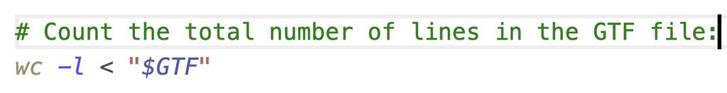

What’s up with the `<`? You can ask Copilot to explain the code it suggests without opening the chat: type your question as a comment line below the command, such as `# How does the < work in the above command?`, then go to a new line and wait for Copilot to suggest an answer as a comment (if it suggests code instead, type `#` first). Here’s the “conversation” I had this way:

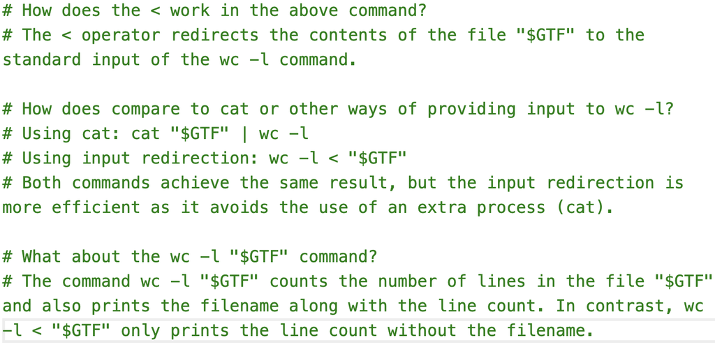

You may not have gotten the same construct, but you can use this trick with any command that Copilot suggests — including those in the next section. This doesn’t use any of your “AI Credits”, since it’s just another code completion (!).

#### Try it for yourself

Next, try some or all of the following prompts in the same way. Copilot is likely to use commands or syntax you haven’t seen yet; in particular, it often uses `awk`. Get Copilot to explain these commands, and optionally dig deeper with Claude Code or Gemini. You can also add notes like “*avoid awk*” and “*use only very basic commands*” to your prompt comments, to see if Copilot can do it in a simpler way.

> # Count the number of gene features in the GTF file

> # Print a frequency table of all feature types in the GTF file

> # Count the number of genes on the + versus the - strand

> # What is the average length of a gene in this GTF file?

Finally, here are a few other example prompts you can try in the same way — these are more general Unix shell tasks that are currently likely just beyond your abilities:

> # Find all Markdown files in /fs/ess/PAS3493 and its subdirs

> # List the top 5 largest files in the /fs/ess/PAS3493 directory and its subdirs

#### Tips and pitfalls

- Overall, mistakes are much more likely here than in the (Claude Code) chat, because it will use a low-tier model, and sometimes also because it has less context to work with. For example:

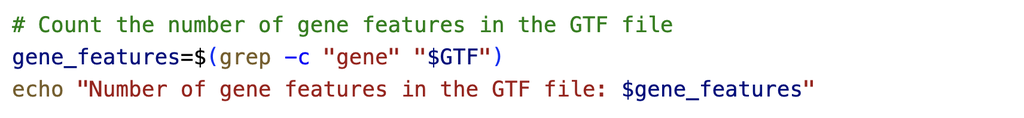

  This suggestion is wrong, because the string gene can occur in many lines  
  that do not represent a gene-level feature in the GTF file.

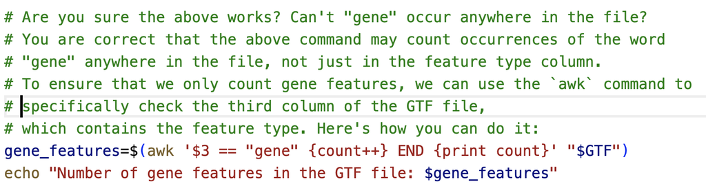

  You can follow up with a comment asking Copilot to fix the command, and it may do so.
- Sometimes, multiple suggestions are available for a prompt, and you can hover over the ghost text to see them.
- After you’ve accepted and run a command, go to a new line, type only a comment symbol (`#`), and wait: Copilot will often suggest a next step that builds on the previous command. See where that leads you, and whether it makes sense!
- Think of something you want to do, start typing the command yourself, and see if and how Copilot completes it.

## 5 Next edit suggestions

[“Next edit” suggestions](https://code.visualstudio.com/docs/editing/ai-powered-suggestions#_next-edit-suggestions) suggest a change to code or other text **that you have already written**. Several kinds of situations can trigger next edit suggestions, such as:

- Syntax, spelling, or style errors in your code, such as a missing closing bracket or quote.
- Changing one instance of a recurring pattern in your code, such as a variable name or a path: Copilot will then suggest to change the other instances as well.

(There isn’t always a bright line between these two kinds of situations.)

### 5.1 Fixing errors

As a very simple example of the first kind, type the incorrect `Ls -lh` in your `copilot.sh` file, and wait a second: Copilot should suggest changing it to `ls -lh`, with a lowercase `l`:

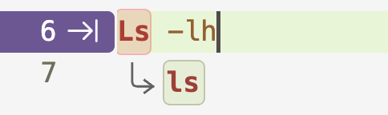

`Ls` is incorrect, and Copilot recognizes that we are looking for `ls` instead.  
As always, press `Tab` to accept the suggestion.

### 5.2 Recurring patterns

When you change one instance of a recurring pattern, such as a sample ID, a variable name, or a file name, Copilot will often suggest changing the other instances as well. We’ll go through two examples.

#### A shell script for a single sample

Create a new file `fastq_summary.sh`, and paste the following script into it. This script summarizes the FASTQ files for sample `S63` (you don’t need to run it):

```
fastq_summary.sh
```

```bash
#!/bin/bash
set -euo pipefail

# Summarize the FASTQ files for sample S63
R1=../garrigos/fastq/S63_R1.fastq.gz
R2=../garrigos/fastq/S63_R2.fastq.gz
outdir=results/fastq_summary/S63

mkdir -p "$outdir"

# Count the number of lines in each FASTQ file
n_R1=$(zcat "$R1" | wc -l)
n_R2=$(zcat "$R2" | wc -l)

# Write the line counts to a TSV file
echo -e "S63\tR1\t$n_R1" > "$outdir"/S63_counts.tsv
echo -e "S63\tR2\t$n_R2" >> "$outdir"/S63_counts.tsv

# Save the first read of each file
zcat "$R1" | head -n 4 > "$outdir"/S63_R1_first-read.txt
zcat "$R2" | head -n 4 > "$outdir"/S63_R2_first-read.txt

echo "Done with sample S63"
```

Let’s say that you now want to summarize the FASTQ files for sample `S64` instead. Change `S63` to `S64` in the line that starts with `R1=`, and wait a second: Copilot is likely to suggest changing the next instance as well. Press `Tab` to accept a suggestion, `Tab` again to move on to the next suggestion, `Tab` again to accept that one, and so on. Did Copilot catch all instances of `S63`, including the ones in the comment line and in the final `echo` command?

A better solution would be to make the script work for any sample, by having it accept the sample ID as an argument, as you learned in week 7. To do so, first add the line `sample_id=$1` above the `R1=` line. Then, change the `R1=` line to:

```bash
R1=../garrigos/fastq/${sample_id}_R1.fastq.gz
```

Copilot should now suggest replacing the other hard-coded sample IDs with `${sample_id}` as well. Check its suggestions carefully: for example, does it keep the curly braces in `${sample_id}_counts.tsv`? Without them, the shell would look for a (nonexistent) variable `sample_id_counts`.

#### An R script

Next edit suggestions are not limited to changing identical pieces of text. The R script below uses the built-in `iris` dataset to summarize, plot, and test the sepal length of three iris species. Even if you don’t know R yet, you should be able to follow along. Create a new file `iris.R`, and paste the following code into it (again, you don’t need to run it):

```
iris.R
```

```r
library(ggplot2)

# Mean sepal length per species
aggregate(Sepal.Length ~ Species, data = iris, FUN = mean)

# Boxplot of sepal length per species
p <- ggplot(iris, aes(x = Species, y = Sepal.Length)) +
  geom_boxplot() +
  labs(y = "Sepal length (cm)", title = "Sepal length by species")
ggsave("sepal_length_boxplot.png", p)

# Test whether sepal length differs between versicolor and virginica
iris_sub <- subset(iris, Species != "setosa")
t.test(Sepal.Length ~ Species, data = iris_sub)
```

Note that sepal length is referred to in four different ways in this script: “sepal length” in the comments, `Sepal.Length` as the column name, “Sepal length” in the plot labels, and `sepal_length` in the file name. So, if you wanted to switch to a different variable, a single find-and-replace wouldn’t do the trick.

Change “sepal length” to “petal width” in the first comment line, and see whether Copilot suggests changing `Sepal.Length` to `Petal.Width` in the next line. Keep pressing `Tab` to see if it also updates the plot labels, the output file name, and the other comment lines.

This works in the other direction, too: change `geom_boxplot()` to `geom_violin()` to make a violin plot instead, and see whether Copilot suggests updating the “Boxplot” comment and the `_boxplot.png` part of the file name.

**TipCode completions and your data**

Code completions mainly use the file you’re working in, and other open files, as context. So if you use them only in your code and documentation files, and don’t open data files while doing so, you are unlikely to send any of your data to GitHub, even if your workspace contains data files. This is different for the chat, especially in Agent mode (see below): an agent can read any file in your workspace, and the output of the commands it runs.

## 6 The chat sidebar

Just like for Claude, the secondary side bar hosts the chat. Open it by clicking the icon shown on the right, then make sure that the “`CHAT`” tab is selected.

**NoteOther ways to open the chat sidebar *(Click to expand)**

- You can use the keyboard shortcut `Ctrl`+`⌘/Alt`+`I` to directly open the “`CHAT`” tab in the secondary sidebar.
- You can click the “sparkling chat box” icon in the top bar, shown in this screenshot:

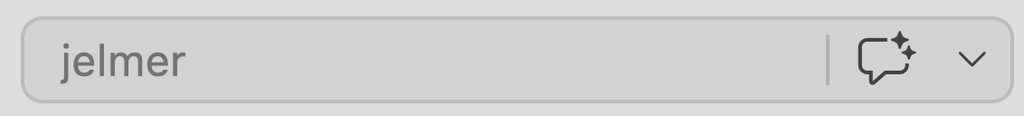

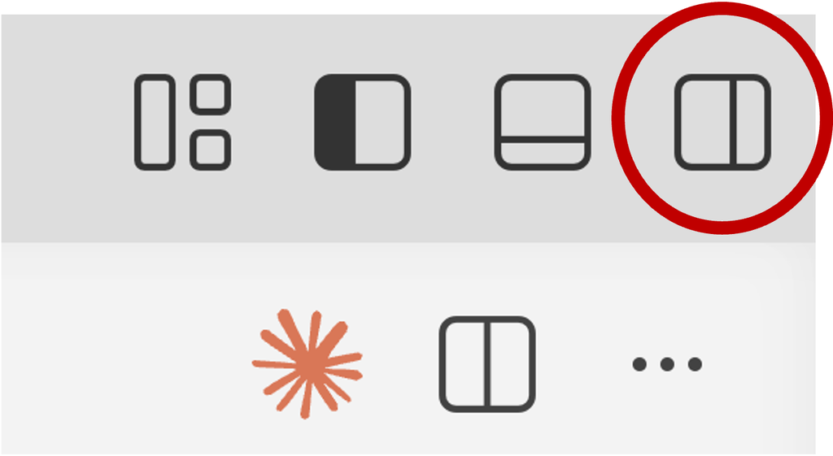

The chat sidebar should open on the right side of your VS Code window, and look something like the screenshot below.

### 6.1 Chat panel interface

As shown in the screenshot, the chat panel has a text box at the bottom where you can type your prompts. Across the bottom of that box are the following buttons:

- `+` adds file **context**
- `Agent` is the currently selected **mode**, and clicking it allows you to select others.
- `Auto` is the currently selected **model**, and clicking it allows you to select others (but this is plan-dependent: see below).
- The dials icon allows you to “*configure tools*”, i.e. to select which tools the agent can use to answer your questions (not something you need to change for now).

Below the text box are buttons to set where the agent runs (`Local`) and the permission level (`Default Approvals`): see below.

Way at the top is a `+` button to start a new chat.

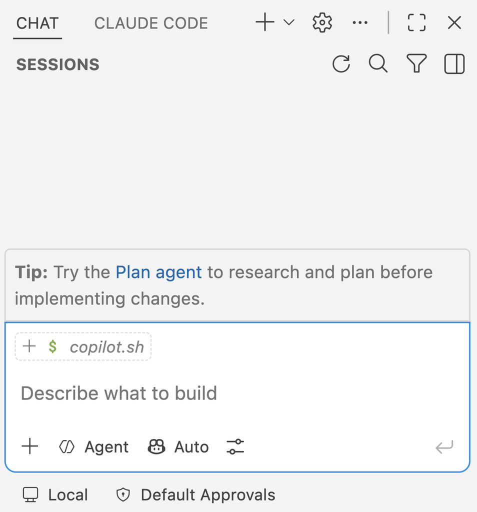

The GitHub Copilot chat sidebar, with the “`copilot.sh`” file suggested as context.

### 6.2 Approval levels

The approval levels are similar to Claude’s permission modes, but not equivalent. The available approval levels are:

- **Default Approvals** falls between Claude’s Manual and Edit automatically modes. Like in Manual mode, Copilot runs common read-only commands without asking, and asks for permission before running other commands. But like in Edit automatically mode, it doesn’t ask before editing files in your workspace (except for “sensitive” files like settings files): it saves its edits right away, and you can then keep or undo each one.
- **Bypass Approvals** lets Copilot do everything without asking, including running any command. But it still works like a regular chat turn: it may stop to ask you a question, or stop when it runs into an error.
- **Autopilot** goes one step further: besides doing everything without asking, it also answers its own questions, and retries on errors, so it keeps going until *it* decides the task is done.

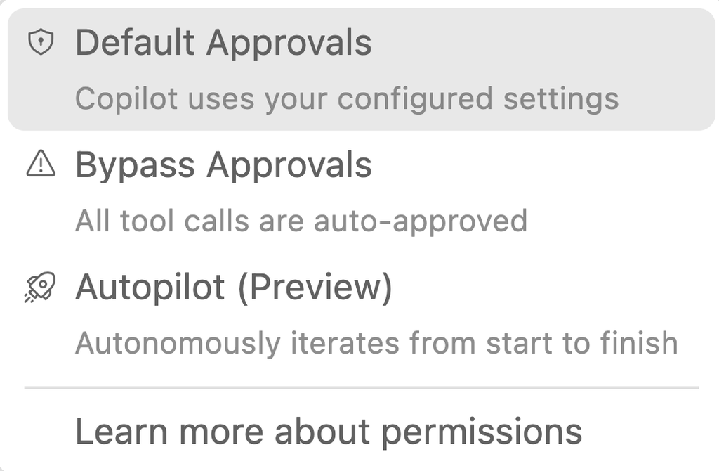

The approval level menu, with “Default Approvals” selected.

Note that neither Bypass Approvals nor Autopilot has the AI safety check that Claude’s Auto mode has: they really skip all approvals, including for destructive commands[^4]. (And whereas Plan is one of Claude’s permission modes, it is one of the chat modes in Copilot: see below.)

**NoteThe `Local` button *(Click to expand)**

The `Local` button below the box sets *where* the agent runs. You’ll only need the default, `Local`, which runs it right here in VS Code on your own files. The other options hand the task off to a separate agent that works in the background: `Copilot CLI` runs Copilot’s command-line agent on the machine where VS Code runs (here, at OSC), `Cloud` runs Copilot on GitHub’s servers (and opens a pull request with its changes), and `Claude` uses Anthropic’s Claude agent instead of Copilot’s own.

### 6.3 File context

Just like Claude, Copilot can search and read files in your workspace (the folder open in VS Code) by itself. And like in Claude, you can point it to specific files:

- **The file that’s active in the editor** is *suggested* as context. Assuming you still have it open, you should see `copilot.sh` at the top of the chat box as shown in the screenshot on the right. However, unlike in Claude, it is *not* added automatically: click the `+` button next to the file name to add it.
- **Other files** can be added with the `+` button at the bottom left of the chat box, or by typing `#` followed by part of a file name (in Claude, you used `@` for this).
- **Lines of code** that you select in the editor are added as context, just like in Claude.

**TipFile/context tips**

As with Claude, it’s often better to point Copilot to the relevant files explicitly, rather than letting it search for them. Even if not explicitly pointed to, Copilot is more likely to pay attention to the files you have open in the editor, so when asking questions, consider opening relevant files and closing irrelevant ones.

### 6.4 Modes

The second button from the left at the bottom of the chat box lets you select different **chat modes**[^5]. The button will show the currently selected mode, which is usually `Agent` by default. Click it to see the menu with the three built-in modes:

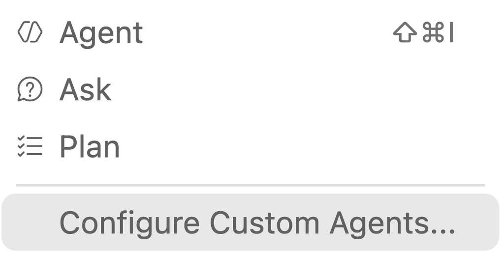

The options in the modes/agents menu.

1. **Ask** — Copilot answers questions, but doesn’t change any files or run any commands. Claude doesn’t have a mode like this, which is why we recommended using a browser-based chat for general questions.
2. **Agent** — Copilot can search your files, create and edit files, and run commands. This is the mode that is most similar to how we used Claude in class.
3. **Plan** — Just like Claude’s Plan mode, Copilot looks around your files without changing them, and writes a plan for a bigger task. Once you’re happy with the plan, Copilot switches to Agent mode to carry it out.

(The last item in the dropdown, *Configure Custom Agents…*, lets you create your own modes, each with its own instructions and a list of tools it may use — for example, a “reviewer” mode that can only read your files and comment on your code. You won’t need this for now, as the three built-in modes cover most use cases.)

### 6.5 Models

While Claude can only use Anthropic models, GitHub Copilot lets you choose between LLMs from different providers, like GPT, Claude, Gemini, and others.

However, on the Free and Student plans, you can only use whatever model Copilot automatically picks for each request — there’s no model dropdown to choose from. (Pro and other paid Copilot plans do let you manually pick a specific model.)

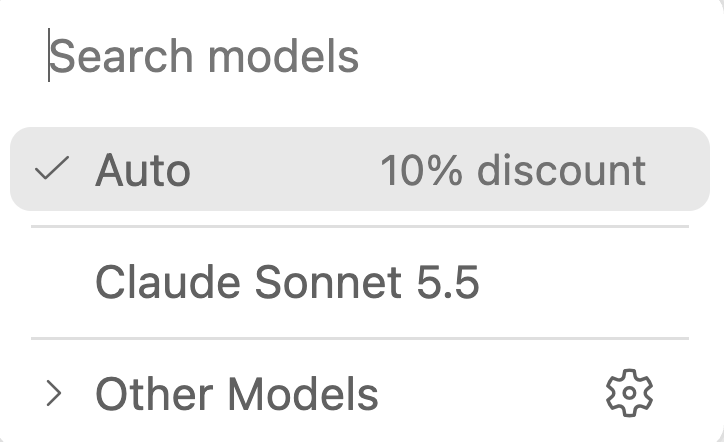

Here’s what the menu looks like on a Pro plan, where you can select a model.

## 7 Chat examples

### 7.1 An example in “Ask” mode

Ask mode is most useful when you want Copilot to look at your files, but not change anything or run commands. For example, you can ask it to explain what a script does, why a certain line in it fails, or which of your scripts creates a certain output file. In Agent mode, Copilot may start editing files or running commands when all you wanted was an explanation.

To keep this first example simple, well ask a general question that doesn’t involve your files (just note that in your actual research, such questions may be better asked to Gemini, so you don’t use up your Copilot credits). Select “Ask” mode and type the following prompt:

> *In a Bash script with set -euo pipefail, why could the line* *zcat sample.fastq.gz | head -n 8 make my script stop with an error,* *even though the FASTQ file is fine?*

Does its explanation make sense to you?

**Click to see a possible answer**

*Here’s the answer I got from Copilot:*

With `set -euo pipefail`, the pipeline’s exit status is treated as a failure if **any** command in it fails.

In:

```bash
zcat sample.fastq.gz | head -n 8
```

what often happens is:

1. `head -n 8` reads 8 lines, then exits normally (`0`).
2. The pipe closes because `head` is done.
3. `zcat` is still writing, gets `SIGPIPE` (broken pipe), and exits non-zero (commonly `141`).
4. Because of `pipefail`, the pipeline status becomes non-zero.
5. Because of `-e`, your script exits.

So the FASTQ can be perfectly fine; it’s a **broken-pipe side effect** from intentionally truncating output with `head`.

Typical fixes:

1. Ignore that specific pipeline failure:

   ```bash
   zcat sample.fastq.gz | head -n 8 || true
   ```

2. Temporarily disable `pipefail` around this command:

   ```bash
   set +o pipefail
   zcat sample.fastq.gz | head -n 8
   set -o pipefail
   ```

3. Use a command that can stop decompressing cleanly for small previews (depends on tools available), but the above is the common practical fix.

Most robust pattern in strict-mode scripts is to explicitly allow this known benign case.

**Be careful with Copilot’s first suggested fix, `|| true`**

`||` means “or”: the command after it only runs if the command before it fails. And `true` is a command that does nothing except succeed. So, adding `|| true` to a line makes it “succeed” no matter what went wrong.

That solves the problem above, but if the FASTQ file were missing or corrupt, your script would now also carry on as if nothing happened — exactly what `set -e` is meant to prevent. This is a common pattern in AI suggestions: a fix that makes the error go away, but also hides errors you’d want to see.

**NoteTesting Copilot’s explanation *(Click to expand)**

Unlike an agent, Ask mode won’t test its own claims — but you can easily do that yourself. `$?` contains the exit status of the last command: an exit status of `0` means success, and anything else means failure.

First, run the command without `pipefail`, which is the default in the shell:

```bash
zcat ../garrigos/fastq/S63_R1.fastq.gz | head -n 8
echo $?
```

After the 8 lines of the FASTQ file, you should see:

```
0
```

Then, run it again with `pipefail` turned on (`set +o pipefail` turns the setting off again at the end):

```bash
set -o pipefail
zcat ../garrigos/fastq/S63_R1.fastq.gz | head -n 8
echo $?
set +o pipefail
```

This time, after the FASTQ lines, you should see:

```
141
```

Without `pipefail`, the exit status of a pipeline is that of its last command, `head`, which ran successfully. With `pipefail`, a failure of *any* command in the pipeline becomes the exit status of the whole pipeline. Here, `141` means that `zcat` was killed by a “`SIGPIPE`” signal because `head` stopped reading after 8 lines. In a script with `set -e`, that would make the script stop at this line.

When I asked it this, Copilot already suggested a few ways to avoid the problem, but if it didn’t, you could ask it a follow-up question, like “How can I avoid this?”. You could also ask it to further explain something it said, or to give a simpler explanation.

### 7.2 An example in “Agent” mode

Select “Agent” mode. Your workspace is your `week09` dir, which contains the scripts from the lecture and your `CLAUDE.md` file. Let’s ask for a new script:

> *Write a shell script that prints the unique chromosome names in an* *uncompressed GTF file. Use commands like cut and sort, not awk*

**TipWhy “not awk”? And thoughts on providing constraints. *(Click to expand)**

For tasks with tabular files like GTF files, AI tools tend to use `awk`, a powerful command that is really its own language, and that we haven’t covered in this course other than briefly this optional self-study section. More broadly, telling the agent which commands to use keeps its code readable for you. If you always want this, you could add a line like “In shell scripts, don’t use `awk`” to your `CLAUDE.md`.

Also, I asked for an uncompressed GTF file to avoid a more complicated script. Agents can be very eager to dot all the i’s and cross all the t’s, and may suggest complicated scripts that handle compressed files, check for errors, etc. This is certainly good in a way, but there is also a cost: you may end up with scripts that you don’t understand, and you become dependent on the AI to maintain them.

- Like Claude would, Copilot will probably first search your workspace, and look at any existing scripts: you should see this being reported in the chat panel.
- It should also read the `CLAUDE.md` file you created in the lecture on Claude, adjust its code accordingly, and even **write a diary entry** in the `doc/ai/claude-diary.md` file as instructed in that file.
- It will likely want to make the script executable and/or test-run it, and will ask for permission to do so, e.g.:

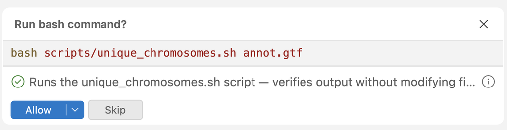

- Unlike in Claude’s “Manual” permission mode, where Claude asks permission before it edits a file, Copilot **makes the edits** right away and saves them to disk (that’s how it can test-run a new script) — but they are still pending your review: you can keep or undo them, as we’ll see below.
- When Copilot is done, you should see an “x files changed” (x is likely 2, as in the screenshot) message at the top of the chat box. You can click the arrow to see the file names, and click on them to open them in the editor:

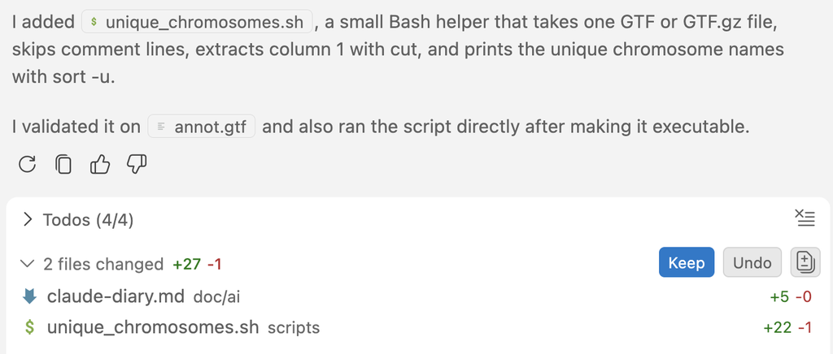

- The file explorer should also highlight the new and changed files with these dot-in-box icons:

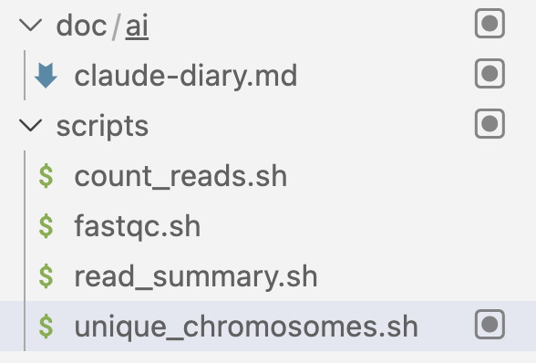

- As mentioned, you can still keep or undo the changes that Copilot made. When you open one of the changed files, you should see a diff view like this, where the lines highlighted in green are the new lines that Copilot added:

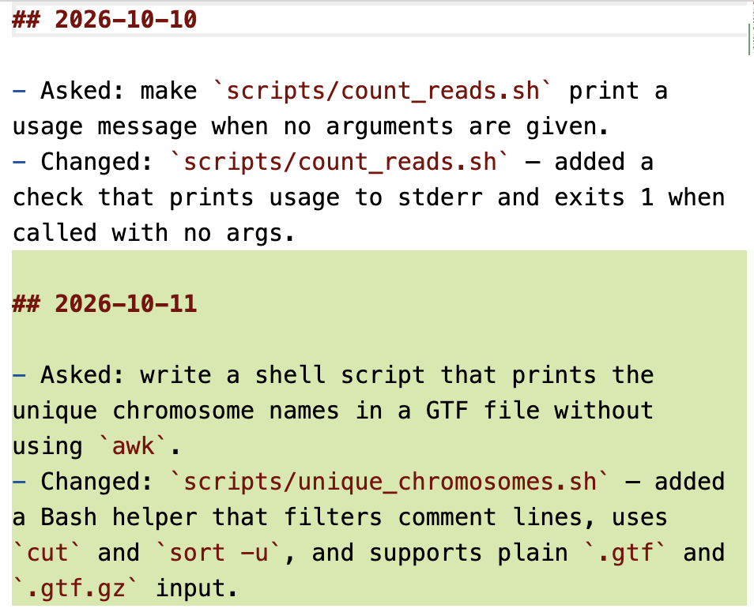

**Click to see some additional screenshots**

- Here, you can see that it looked at the other files in the workspace to determine what it should do:

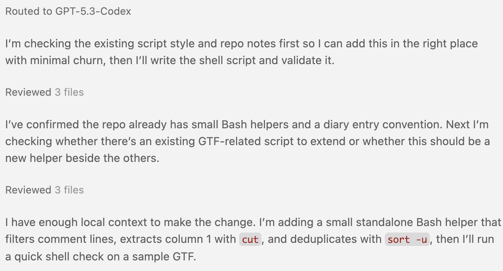

- Here, its first test-run of the script failed because it didn’t use the correct path for the GTF file:

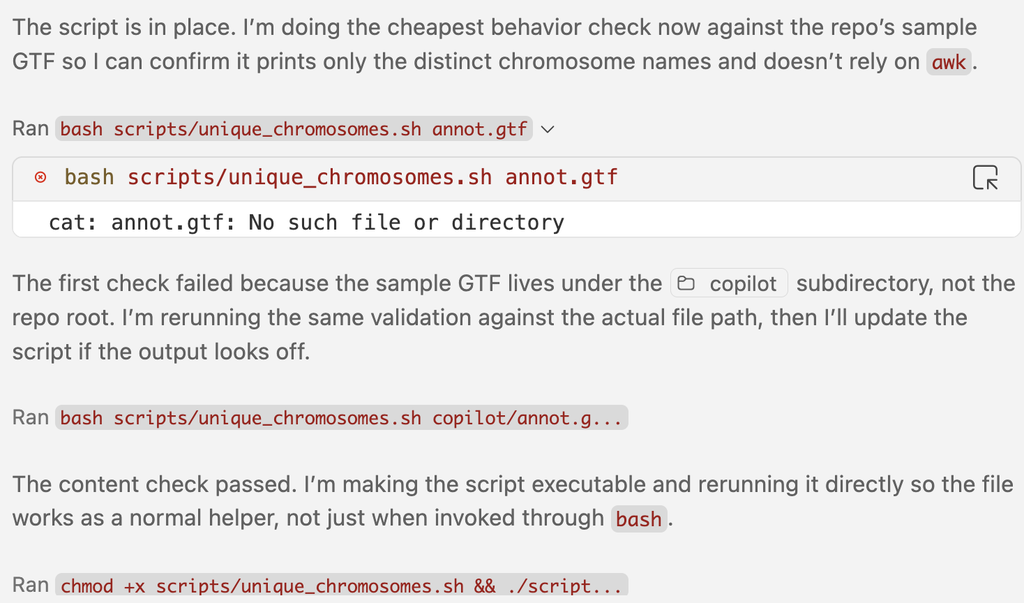

- Then, it fixed the path and asked for permission to run the command again:

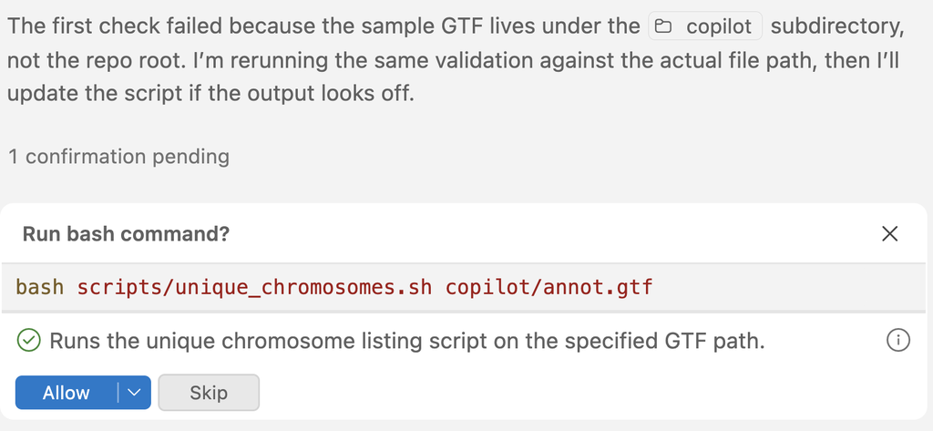

- Finally, it talks about the diary entry that `CLAUDE.md` instructs it to write, and it also saves a note in its own memory file — like Claude, Copilot keeps memory notes for itself:

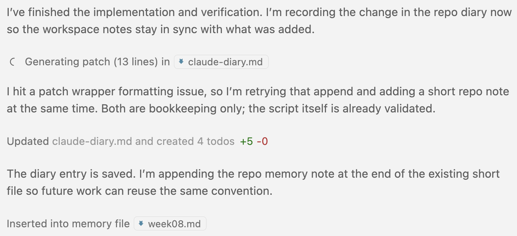

#### Exercise 2: Check the agent’s work

- Did Copilot look at other files before writing the script? Did it report reading `CLAUDE.md` and did it write a diary entry in `doc/ai/claude-diary.md`? Does the new script follow the shell script conventions in your `CLAUDE.md`?
- Where did it save the script, and why there?
- Did it do exactly what you asked, or did it add things you didn’t ask for?
- Run the script on the `data/annot.gtf` file. Does the output look reasonable?
- The GTF file starts with a few header lines that begin with `#`. Predict what the simple command `cut -f 1 data/annot.gtf | sort -u` would print for those lines. Does the output of Copilot’s script contain such lines? Look at the script to see how it handles them.

**Click to see a hint for the last question**

Header lines contain no tabs, and when a line has no delimiter, `cut` prints the whole line. So each header line would show up as if it were a chromosome name. (My script first removed these lines with `grep -v '^#'`: does yours?)

Next, ask for an edit to that script:

> Make the script write its output to a file, which is passed as the second argument

When it’s done and you open the modified script, you should see a diff that highlights both additions and deletions:

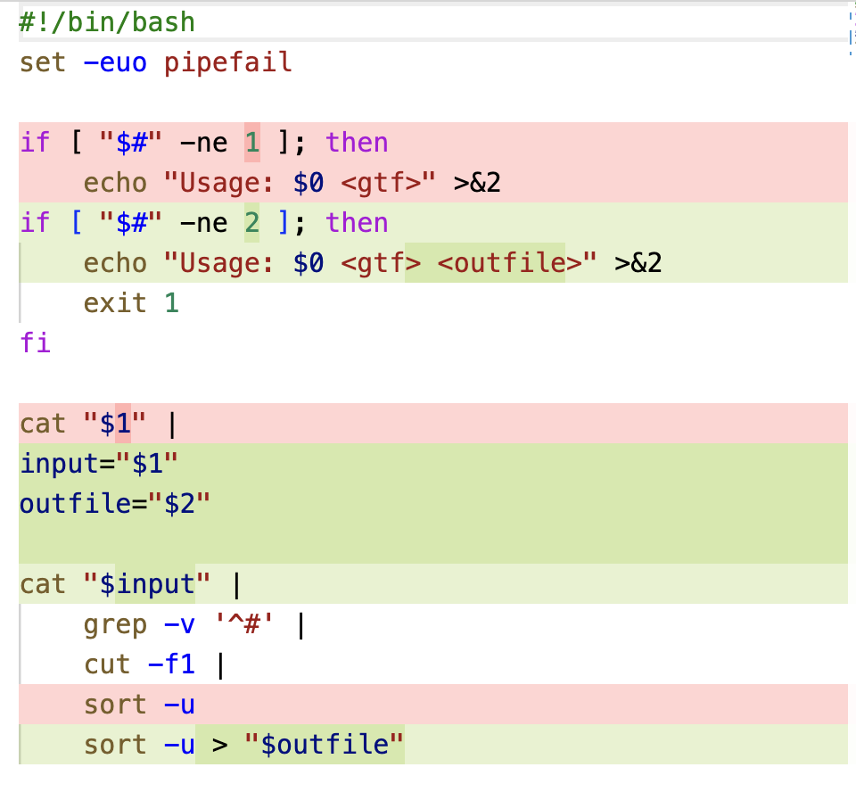

And the final script may look something like this. (It’s using an if-statement to check whether two arguments were passed to the script, and if not, it prints a usage message and exits with an error code. For more about this, see the optional self-study section on if-statements.)

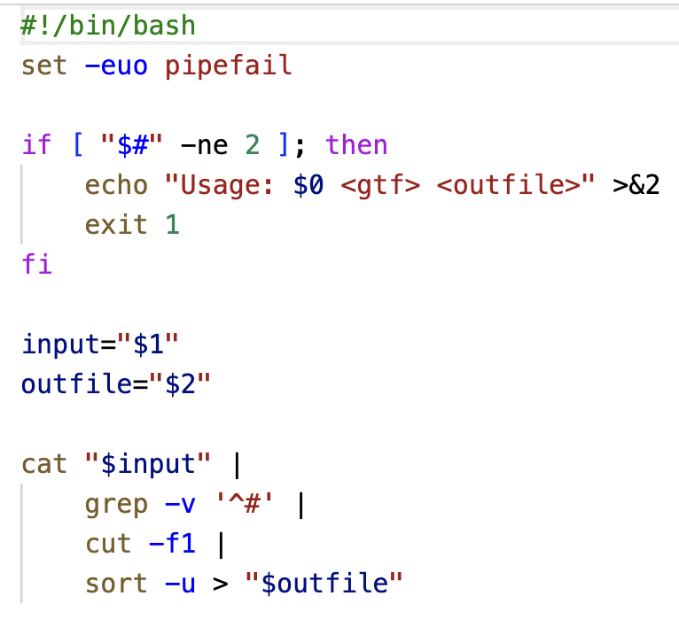

**NoteCopilot custom “background” instructions**

As mentioned above, and as you should have witnessed in the previous example, Copilot in VS Code reads the same `CLAUDE.md` file as Claude. Therefore, any persistent instructions you wrote for Claude also apply to Copilot. It also reads `AGENTS.md`, the equivalent file that many other AI coding tools use.

## 8 Appendix: Inline chat

While technically part of Copilot’s chat features, **inline chat** is a final in-editor feature that dovetails nicely with code completions: you select a piece of code and ask Copilot to modify or explain it, right there in the editor. (Claude doesn’t have inline chat: there, you would select the lines and ask about them in the side bar.)

### 8.1 Modify code

When you are not happy with a ghost text suggestion, you can delete it, modify your comment line, and press `Enter` again. But you can also explicitly request a change to the code with inline chat, by selecting the code and pressing `⌘`+`I` (Mac) / `Ctrl`+`I` (Windows).

For example, here, I got an incorrect answer to the comment prompt “How many genes have a description?”:

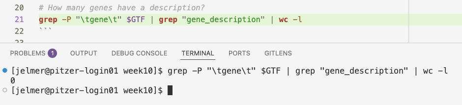

So I pressed `⌘`+`I` and reported the failure:

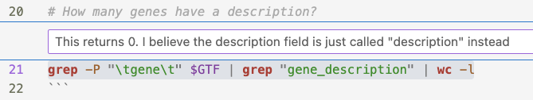

Copilot then came up with a fix, which I could accept:

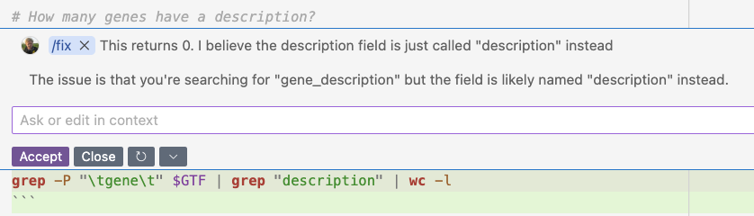

Running the modified line did give the correct answer:

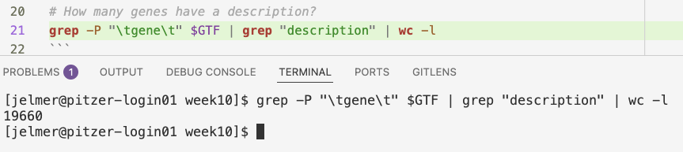

Inline chat also works in the terminal: when you type a command in the terminal and press `⌘`+`I` / `Ctrl`+`I`, the inline chat box opens there and works on that command.

### 8.2 Explain code

To have Copilot explain code instead, select it, open inline chat, type the “slash command” `/explain`, and press `Enter`:

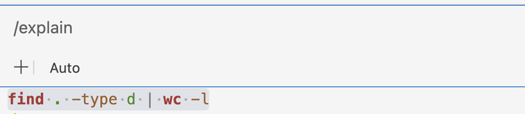

For the selected line in the screenshot, `find . -type d | wc -l`, you should get a response like the following:

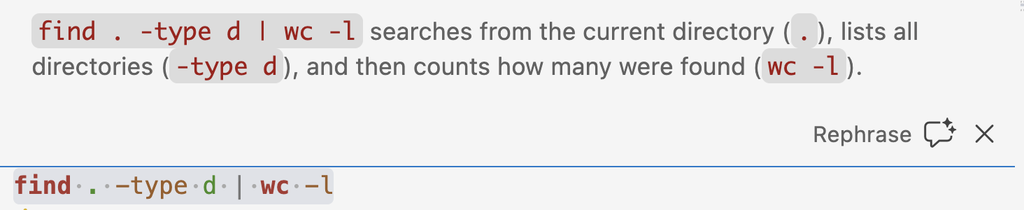

#### Exercise 3: Inline chat

1. Select the command that Copilot suggested for “What is the average length of a gene in this GTF file?”, and ask Copilot to explain it with `/explain`. Do you understand each part of the command now? If you also asked about this command with a comment line earlier, how does that explanation compare?
2. Select the command that Copilot suggested for “Print a frequency table of all feature types in the GTF file”, and use inline chat to ask Copilot to change it so that the table is sorted from most to least common feature type (or, if it already was, from least to most common). Then run the modified command to check the result.

**WarningInline chat counts as chat, not as a code completion**

On the Student and Pro plans, code completions are unlimited, but inline chat requests use your monthly “AI Credits”, just like requests in the chat side bar. You can check how much you have used by clicking the Copilot icon in the status bar.

**NoteGitHub Copilot resources**

- [Best practices for using GitHub Copilot](https://docs.github.com/en/copilot/get-started/best-practices) (GitHub docs)
- [Some prompt writing tips from a GitHub blogpost](https://github.blog/developer-skills/github/how-to-write-better-prompts-for-github-copilot)
- [VS Code’s GitHub Copilot documentation](https://code.visualstudio.com/docs/copilot/overview)

Back to top

## Footnotes

[^1]: Note: If you get a personal account, you will be responsible for any costs associated with its use and it will not be OSU-approved
[^2]: Quite limited without educational benefits, but more useful as a student: see below.
[^3]: GitHub and VS Code are both Microsoft products. Google Gemini also has a VS Code extension with similar functionality, but when I logged in with OSU credentials, I was informed that this is not available to us.
[^4]: In newer versions of VS Code, these levels may be called “Manual permissions” and “Allow all”, Autopilot may have moved to the modes menu, and an experimental “Assisted permissions” level with an AI check, like Claude’s Auto mode, may be available: see the [VS Code documentation](https://code.visualstudio.com/docs/agents/run/approvals) .
[^5]: VS Code calls these “agents” rather than modes, but “mode” is clearer here, since all three are run by the same AI.